# Dates-as-Data for Inscriptions

Using SPA with Latin epigraphic databases to investigate changing complexity in the Western Roman Empire — RAC-TRAC 2026, TRAC7, Aarhus

Adela Sobotková (Aarhus University) — presenting

Shawn Ross (Macquarie University) — author, in absentia

May 22, 2026

## 1 · The dates-as-data tradition, and a persistent puzzle

- 40 years of “dates as data” in archaeology (Rick 1987; Timpson et al. 2014; Crema & Bevan 2021)
- LIRE v3.0: **180,609 inscriptions**, 50 BC – AD 350 (Kaše et al. 2023)
- **The recurring objection** — the **epigraphic habit** (MacMullen 1982; Hanson 2021)
- **Our question**: how much demographic signal survives editorial distortion?

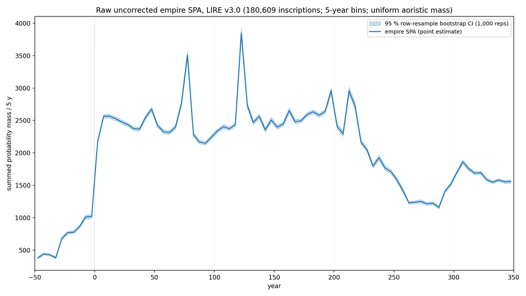

Raw empire-wide SPA, LIRE v3.0 (180,609 inscriptions, 5-year bins, uniform aoristic). Thin band = 95 % row-resample bootstrap CI.

## 2 · Editorial distortion has a measurable signature

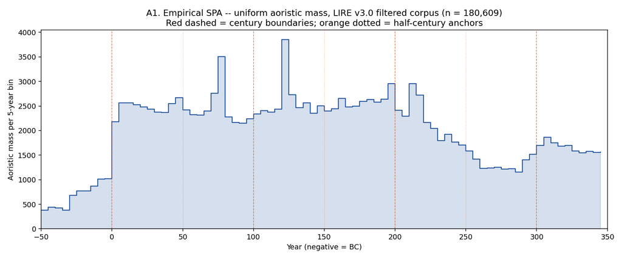

- **54.5 %** of `not_before` end in `01`; **53.0 %** of `not_after` end in `00`
- Largest step in the SPA: **+1,159 at the 1 BC / AD 1 boundary**
- Narrow spikes at AD 77.5 (Flavian), 122.5 (Hadrianic), 212.5 (Severan)

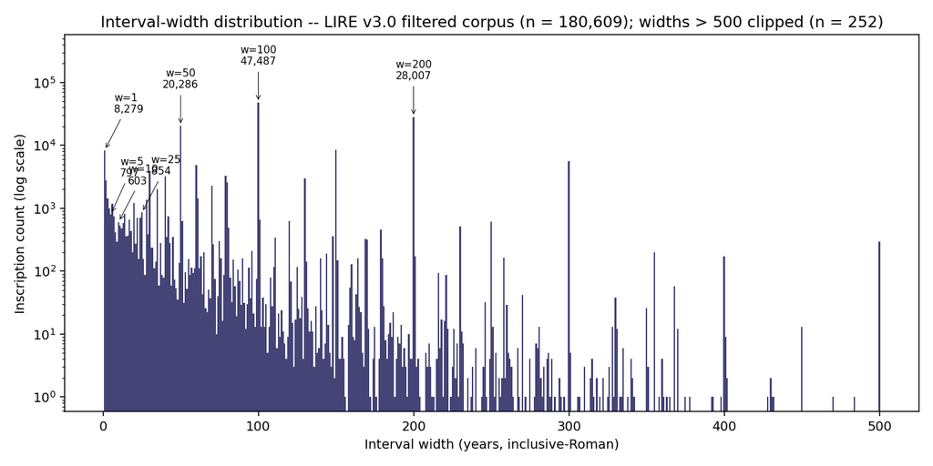

**Reading the signature**:

- Wide templates → editorial encoding artefact
- Narrow spikes → real ancient clustering (sustain under high-precision filter)

## 3a · A power simulation: which analyses are reachable?

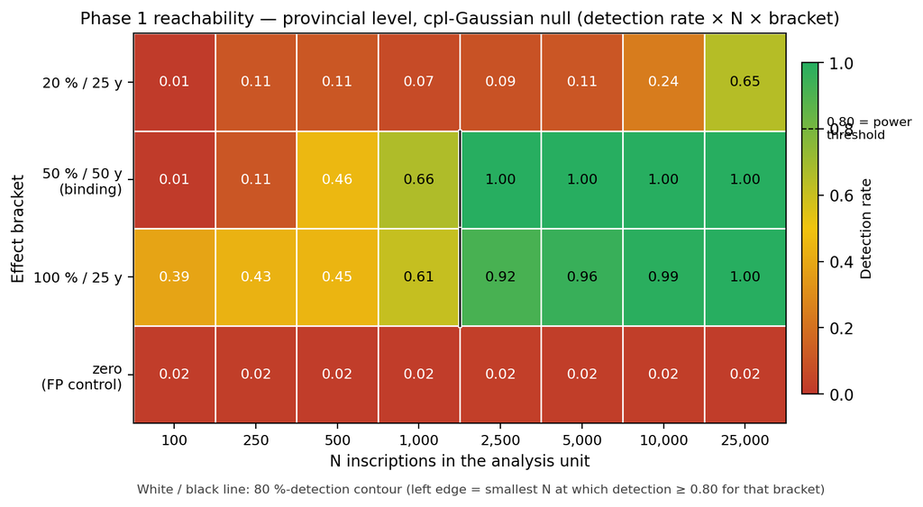

Synthetic corpora with **known** deviations → run through the detection method → measure detection rate.

For the binding bracket:

- **Empire**: reachable at n = 50,000 *(only n tested at empire scale)*
- **Province / urban-area**: min n ≈ **1,600** *(range 1,400 – 1,950 across nulls)*
- False-positive control ≤ 5 % across all 96 zero-effect cells

## 3b · Reachability across sample size and effect size

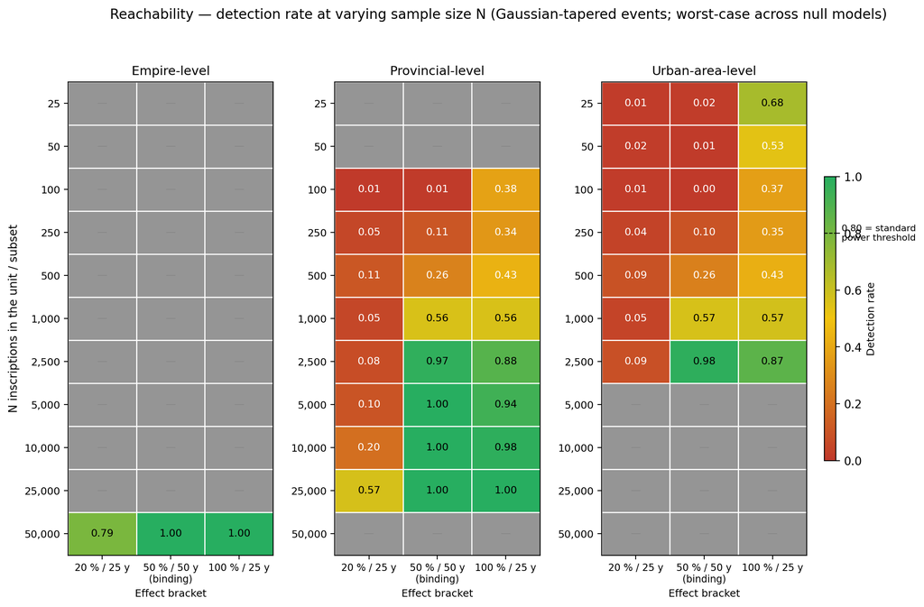

Detection rate by N (rows) × effect bracket (columns). Grey cells = combination not in the simulation grid for that level.

**Practical reads**:

- **N < 1,000** → nothing reliably detectable
- **50 %/50 y** events → need **N ≈ 2,500**
- **20 %/25 y** events → unreachable at any practical N
- Smaller subsets → cross-sectional (slide 6b) + descriptive (slide 4) instead

## 4 · What the data look like at multiple scales

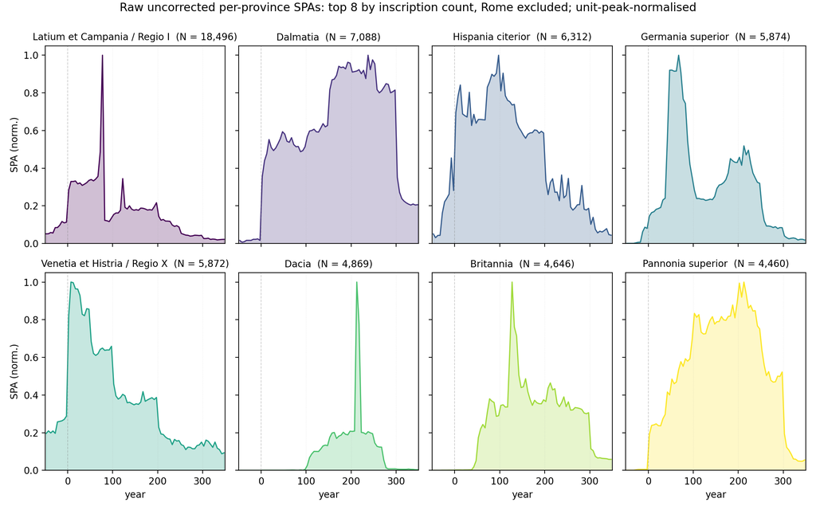

Top 8 provinces by inscription count (Rome excluded); raw uncorrected SPAs, unit-peak-normalised.

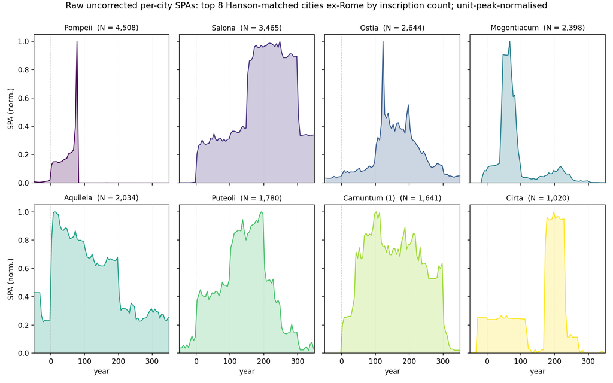

Top 8 Hanson-matched cities (Rome excluded); raw uncorrected SPAs, unit-peak-normalised.

## 5 · Correcting editorial artefacts: Bayesian mixture decomposition

**The idea**:

- Split the observed SPA into **editorial encoding** (template intervals) **+ real ancient production** (smooth signal)
- Estimate **what fraction (α) is editorial** at the empire level
- Validate by **recovering known answers from synthetic data**

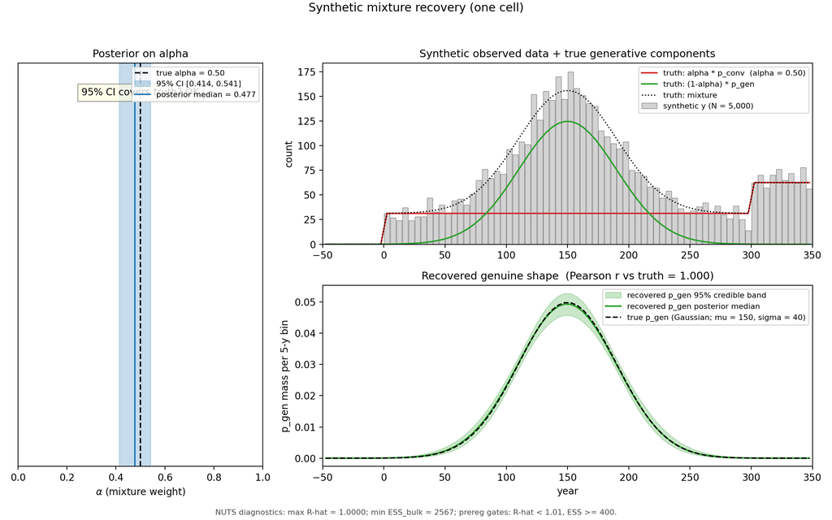

Synthetic cell, N = 5,000, true α = 0.50. **α posterior covers truth** (median 0.477, 95 % CI [0.414, 0.541]); **shape Pearson r = 1.000**. *Schematic only; full grid post-talk.*

## 6a · Does Hanson population predict inscription count?

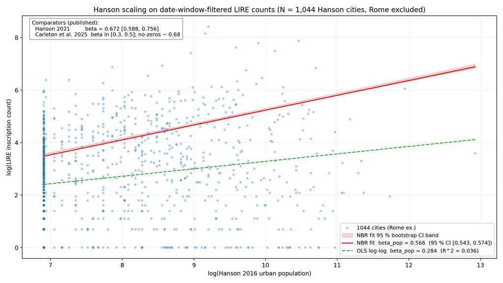

Log–log scatter, 1,044 Hanson-matched cities (Rome excluded). NBR fit (red, with 95 % bootstrap CI band); OLS log-log fit (green dashed).

**Sublinear scaling**: bigger cities produce *proportionally fewer* inscriptions per capita.

| Source | β |
| --- | --- |
| **Our NBR** | **0.566** |
| Hanson 2021 | 0.672 |
| Carleton 2025 (no-zeros) | ~ 0.68 |

Our 95 % bootstrap CI: [0.543, 0.574].

## 6b · How much of the variation is population, vs. everything else?

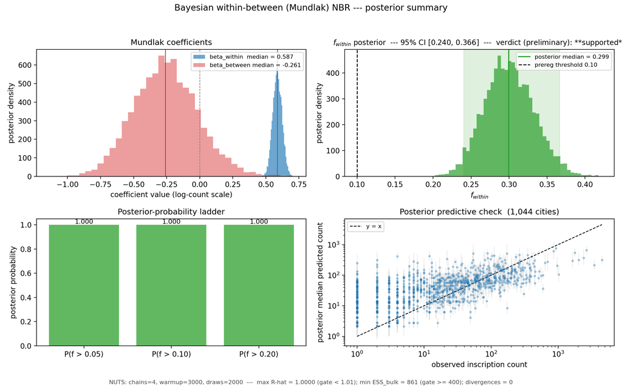

**Compare cities *within* a province** — that strips out province-wide effects (habit, administration, survival) and isolates the population signal.

**Result** (1,044 cities ex-Rome):

- **~ 30 %** of city-to-city variation → within-province population
- **~ 70 %** → habit, convention, survival, admin structure
- 95 % CI on the 30 % figure: [24 %, 37 %]

## 7 · Where this is heading, and what we’d love feedback on

**Preregistration lodged 2026-05-20**: `osf.io/uycs6` *(embargoed)*

- Mixture validation (recovery grid)
- Mundlak NBR + within-province verdict
- Antonine plague + 3rd-c. Crisis probes
- Provincial-capital residuals + Moran’s I

**Forthcoming**: statistician review; state-space / HMM alternative; trapezoidal-aoristic sensitivity.

**Questions for this room**:

1. **LIRE / SDAM team**: does the editorial-template decomposition match dating practice in EDH / EDCS / LIRE?
2. **Which sub-mechanisms** drive the ~ 70 % non-population variance?
3. **Negative-control subgroups** or **independent demographic anchors**?

**Contact**: Shawn Ross · `shawn@fieldnote.au` — feedback warmly welcomed.

## Deep dive: backup slides for Q&A

The slides that follow address anticipated audience questions. Adela should jump to whichever is relevant using the slide overview (press `o` in revealjs).

## B1 · Why exclude Rome from the scaling fit?

- Rome alone contributes **65,435 inscriptions** to the filtered corpus — **36.2 %** of the total
- As a single observation it dominates the scaling regression
- Hanson 2021 also excludes Rome (Table 7.3 caption) — methodologically consistent
- Reported transparently; **not tested as a sensitivity** (per prereg §9)

## B2 · Why the 50 BC – AD 350 envelope?

- **Late-Republic dating is sparse** (pre-50 BC); inscriptions there don’t carry enough signal for the temporal analyses
- **Post-AD 350 is Late Antique** — different epigraphic conventions, different cultural-political context
- Aligned with **Hanson 2016’s reference period** (100 BC – AD 300; our extension to AD 350)
- Roughly the imperial-era period during which urban populations and inscription production overlap

## B3 · How uncertain are the Hanson population estimates?

- Hanson 2016 estimates are **max-theoretical** (urban footprint × density), not realised peaks
- **Preregistered sensitivity** (Phase 3, post-talk): refit H3a with `log_pop_c ~ Normal(log_pop_observed_c, σ_pop)` for **σ_pop ∈ {0.1, 0.2, 0.3}**
- Flag: if f_within shifts by > 50 % of its CI width under any σ_pop → reported as limitation

## B4 · Why NBR? Why not OLS log-log?

- Inscription counts are **over-dispersed** — variance grows faster than the mean (Negative Binomial dispersion α ≈ 2.15 in our fit)
- **OLS on log(count)** is dragged toward zero by the long tail of cities with N = 1 (log(1) = 0). Our OLS β = 0.284, R² = 0.04 — half the NBR estimate, near-zero explanatory power
- NBR correctly models count variance scaling with mean → β = 0.566, tight bootstrap CI

## B5 · Why not fit the mixture model per-city?

- For ~ 600 of the ~ 1,000 Hanson cities with N < 100 inscriptions, the mixture is **unidentified** — too few counts to separate convention from genuine
- The cross-sectional H3a regression instead uses **the date-window filter** as its artefact protection
- The empire-level mixture α posterior is reported as **descriptive context only**, not propagated into H3a’s variance-fraction CI

## B6 · How does the mixture treat year-precise inscriptions?

- Year-precise inscriptions ([t, t] consular or imperial-titulature dates) are **NOT** part of the convention component
- They remain in `p_gen` as **real ancient anchors**
- The convention component is built only from **wide-template slabs** (century, half-century, reign-interval)

## B7 · Survival and publication bias

- The **between-province** Mundlak coefficient is **not separately identifiable** from province-level survival bias
- The **within-province** coefficient is more defensible — it assumes roughly equal survival within a province (a much weaker assumption)
- LIRE aggregates EDH + EDCS coverage → we inherit their editorial decisions and coverage gaps
- **Reported as limitation** in prereg §9

## B8 · The sample-size footnote: 1,044 vs the prereg’s “~815”

- Prereg quotes “~815 Hanson-matched cities” Rome-excluded
- We use **1,044 cities** — the text-spec-faithful denominator from the LIRE parquet
- The “~815” figure was inherited from a 2024 notebook subset that applied an extra `province_language == 'Latin'` filter via a manually-curated mapping that isn’t in LIRE
- **Logged for the OSF amendment trail**; not a confirmatory deviation

## B9 · Can small-N cities (100–250 inscriptions) tell us anything?

- **For temporal deviation-detection**: NO — Phase 1’s N ≈ 1,600 floor for credible 50%-over-50y detection. Inscription series below this are too sparse for formal inference
- **For descriptive shape claims**: YES — visual peaks / declines / plateaus carry information
- **For the cross-sectional H3a regression**: YES — all 1,044 cities (no minimum N) contribute leverage
- **Layer B inversion** (prereg §5): tentatively map inscription trajectory to illustrative population trajectory under stated assumptions

## B10 · Hanson’s residual findings (Hanson 2021 replication)

If asked about replicating Hanson 2021’s specific findings:

- **Provincial capitals over-produce** inscriptions relative to scaling expectation (Hanson’s mean residual 0.43 vs ~0.06 for *coloniae* / *municipia*)
- **Moran’s I = 0.046** on residuals (significant spatial clustering)
- **Moran’s I = −0.006** on raw counts (no clustering — clustering is in the residuals)
- **Our H3c** is a preregistered replication of both findings (post-talk)

## B11 · Martin’s state-space / HMM alternative

Statistician collaborator (Martin) has proposed a state-space / HMM approach for future methodological work:

- Treats **latent population N_t** as a hidden state under a stationary kernel
- **Aoristic-interval emission** via Cox-process integration (baorista’s existing infrastructure provides the emission layer)
- Genuinely novel for archaeology (no prior art in our literature scout)
- Post-lodgement **OSF amendment** if pursued
- Citations: Kéry & Schaub 2012 (Integrated Population Models); Tingley & Huybers 2010 (BARCAST)

## Methods glossary (for the stats-curious)

Plain-English explanations of the statistical operations in this talk, aimed at intelligent undergraduates from any humanities discipline. Adela should jump to whichever slide answers an audience question (press `o` for overview).

## G1 · What is a Summed Probability Analysis (SPA)?

When we ask “how many inscriptions were produced per decade across the Empire?”, most inscriptions don’t have a single-year date — they’re dated to a *range* like “AD 50–100” or “the reign of Hadrian”. So we can’t just count inscriptions per year.

An SPA treats each inscription’s date as a **probability distribution** over the range it could fall in. An inscription dated AD 50–100 contributes 1/50 of a unit of evidence to each year from 50 to 99. Add up the contributions across all inscriptions and you get a “summed probability” curve — the expected number of inscriptions per year.

The *shape* of the SPA tells you how production varied over time.

## G2 · What is “aoristic” dating?

“Aoristic” means a date is known to be within a range rather than at a point. An inscription with `not_before = AD 50, not_after = AD 99` is aoristic — produced somewhere in that 50-year window.

**Uniform aoristic** is the simplest treatment: spread an inscription’s “1 unit of evidence” *evenly* across its range — 1/50 per year for a 50-year interval. **Trapezoidal aoristic** is an alternative: more mass at the middle, less at the ends (closer to how editors might mentally anchor).

The project uses uniform aoristic as the primary specification and preregistered a trapezoidal sensitivity check. Pilot diagnostics show Pearson r ≈ 0.94 between the two — quantitatively consequential, not qualitatively decisive.

## G3 · What is a power simulation?

A power simulation asks: *if a real effect existed in the data, would my analysis method detect it?*

The procedure:

1. **Construct synthetic data** where you *know* the answer in advance (e.g., plant a 50 %-over-50-year bump in inscription production)
2. **Run your method** on the synthetic data and see whether it detects the planted effect
3. **Repeat 1,000 times per scenario** and measure the detection rate

If detection rate is high (> 80 %), the method is *reachable* at that sample size. If detection rate is low, the method can’t reliably see real effects of that size — you’d be claiming “no effect” even when the effect IS there. Phase 1 (slide 3) is this exercise across 96 combinations of analysis level × subset × effect size.

## G4 · What is a Bayesian mixture decomposition?

A **mixture model** says the observed data is a *weighted sum* of two (or more) underlying components. For our analysis:

observed SPA = α × editorial encoding + (1−α) × real ancient production

The model’s job is to figure out α (the mixing weight) and the shape of each underlying component from the observed total.

**Bayesian** means we get a *probability distribution* over plausible values of α and the underlying shapes — not just a single best guess but a full description of the uncertainty.

The trick that makes this work is that the editorial-encoding component isn’t a free shape — it’s built from a small dictionary of known editorial templates (century slabs, half-century slabs, reign-interval templates). That constraint makes the decomposition *identifiable*: there’s only one way to split the data that fits well.

## G5 · What is Negative Binomial Regression (NBR)?

NBR is a regression model for **count data** — like inscription counts per city. It’s the right tool when:

- The outcome is a non-negative integer (0, 1, 2, …)
- The data is **over-dispersed**: variance grows faster than the mean

For inscription counts, both apply. A typical Roman city might produce 50 inscriptions on average, but the variability across cities is much higher than 50 (which is what a simple Poisson model would predict). NBR adds an over-dispersion parameter that explicitly allows for this.

The NBR coefficient β on log(population) is the **scaling exponent**: expected inscription count grows as population^β. β = 1 means linear scaling; β = 0.566 (our result) means *sublinear* — bigger cities produce *proportionally fewer* inscriptions per capita than smaller ones.

## G6 · What is OLS log-log — and why does it fail here?

OLS (Ordinary Least Squares) is the classic straight-line regression. “Log-log” means both predictor and outcome are log-transformed before fitting.

The published inscription-scaling literature (Hanson 2021, Carleton 2025) uses OLS on `log(inscription count) ~ log(population)`. The trouble for our corpus is that we have many cities with **inscription count = 1**, where `log(1) = 0`. Those cities collapse the bottom of the regression to a horizontal line, **flattening the slope**.

Our OLS log-log result (β = 0.284, R² = 0.04) is exactly this artefact: **half the NBR slope**, with near-zero explanatory power. NBR correctly handles count variance scaling with the mean and doesn’t suffer the low-count distortion.

This isn’t a contradiction with published results: same spec on a different corpus with different filtering can give a very different number (Hanson 2021’s 0.672).

## G7 · What is the Mundlak (within-between) decomposition?

This is the statistical move that lets us **separate** the within-province population effect from province-level “everything else”.

Each city’s `log(population)` is split into two pieces:

1. The **province-mean log(population)** — typical city size in this province
2. The city’s **deviation** from that province mean — how much bigger or smaller than typical

Both enter the regression with their own coefficients. **β_within** is the coefficient on the *deviation* — by construction orthogonal to province membership, so it’s an unconfounded within-province effect. **β_between** is the coefficient on the province mean — explicitly *confounded* with everything else that varies between provinces.

Named after Yair Mundlak (1970s).

## G8 · What does f<sub>within</sub> mean?

**f<sub>within</sub>** is a **variance fraction** — what proportion of the systematic variation in expected inscription count across cities is attributable to within-province population:

f<sub>within</sub> = Var(β<sub>within</sub> × within-province deviation) / Var(total expected log-count across cities)

A value of **0.30** means **30 %** of city-to-city differences in *expected* inscription count are explained by within-province population. The remaining 70 % lives in:

- Province random intercepts — habit, culture, administration, survival (the biggest chunk)
- A small + statistically null between-province population gradient
- Component covariances

A variance fraction (not a slope coefficient) tells you how much of the *variation* the effect accounts for. A slope alone wouldn’t.

## G9 · Bootstrap CIs vs Bayesian credible intervals

Both express uncertainty about a quantity (like β or f<sub>within</sub>) — but they come from different procedures.

**Bootstrap CI (frequentist)** — slide 6a NBR β; slide 1 empire-SPA band. Resample the dataset many times *with replacement*, refit on each resample, take the 2.5th–97.5th percentile. Tells you how much your estimate would change *if you’d sampled slightly different data*.

**Credible interval (Bayesian)** — slide 5 α posterior; slide 6b β<sub>within</sub>, f<sub>within</sub>. The model gives you a probability distribution over plausible parameter values directly; the 95 % credible interval is the central 95 % of that distribution. Tells you where the parameter *probably is*, given the data and the model.

Both read as “95 % intervals” and in our analyses they agree closely — but the underlying inference is different.